# Lab12. Decision Trees and Forests. Variable importance

We will use the library `party`. However, there is a number of other packages for classification and regression tree-based approach (CART): `randomForest`, `rpart`, `crat`, `maptree`, `partykit` and other.

```r
library(party)
```

### 1. Consonant drop in Russian

Our student Varvara Sveshnikova wrote her BA paper on two cases of the consonant drop:  
(a) when in the complex -stvov- (like in *beschinstVovat’* ‘to riot’) another labial consonant is pronounced after it, and  
(b) when no consonant follows (in two contexts: *beschinstVuju* ‘I riot’, beschinstVo_ ‘roistering’).  
The [dataset](https://raw.githubusercontent.com/agricolamz/r_on_line_course_data/master/Sveshnikova.2016.v.elision.csv) includes the following data:  
`v.elision` — elision of [v] / no elision;  
`group` — a group of test words, first (*beschinstvovat’*), second (*beschinstvuju*), third (*beschinstvo*);  
`word` — root under analysis;  
`position` — phrase position: strong, under logical stress (_I am not *CRYING*, I resent), weak (_He ALWAYS likes to *cry*).  
Fit a CART model, using ctree() function, predicting v.elision variable by all others.  
1.1 Visualize a model using plot() function. What is the number of observation in node 6?  
1.2 Visualize a model using print() function. Which split have a statistic 14.01?  
1.3 Predict a value of v.elision for word with a root “попеч” in a third group, in a strong position.

Fit a cforest model using additional argument controls=cforest_unbiased(ntree=1000, mtry=3).  
1.4 Predict a value of v.elision for word with a root “попеч” in a third group, in a strong position using `cforest` model.  
You need to add an argument OOB=TRUE, e. g. yes  
1.5 Calculate a variable importance for a group variable in the random forest model using varimp() function.

Code to use:

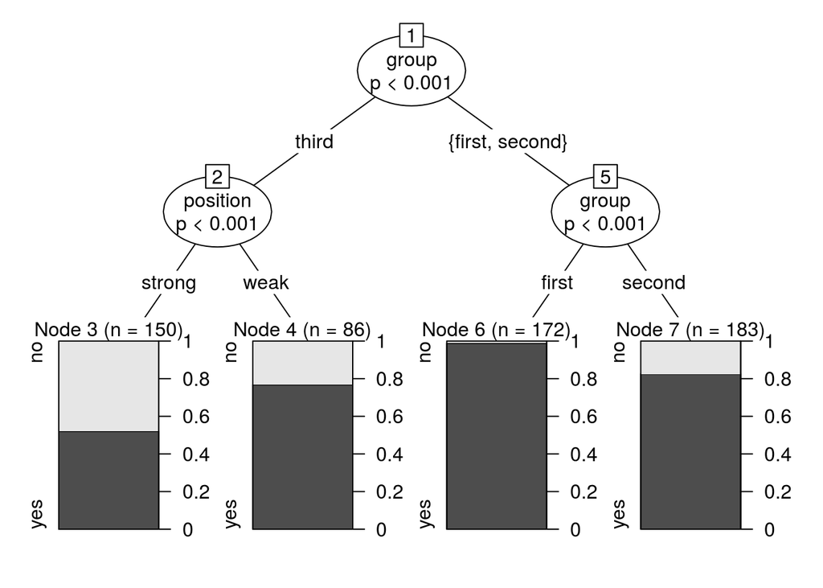

```r
df <- read.csv("https://raw.githubusercontent.com/agricolamz/r_on_line_course_data/master/Sveshnikova.2016.v.elision.csv")
fit <- party::ctree(v.elision~., data = df) # use the argument controls = ctree_control(...) to control the max depth etc.
plot(fit)
```

```r
print(fit)
```

```
##
##   Conditional inference tree with 4 terminal nodes
##
## Response:  v.elision
## Inputs:  group, word, position
## Number of observations:  591
##
## 1) group == {third}; criterion = 1, statistic = 87.011
##   2) position == {strong}; criterion = 0.999, statistic = 14.01
##     3)*  weights = 150
##   2) position == {weak}
##     4)*  weights = 86
## 1) group == {first, second}
##   5) group == {first}; criterion = 1, statistic = 27.204
##     6)*  weights = 172
##   5) group == {second}
##     7)*  weights = 183
```

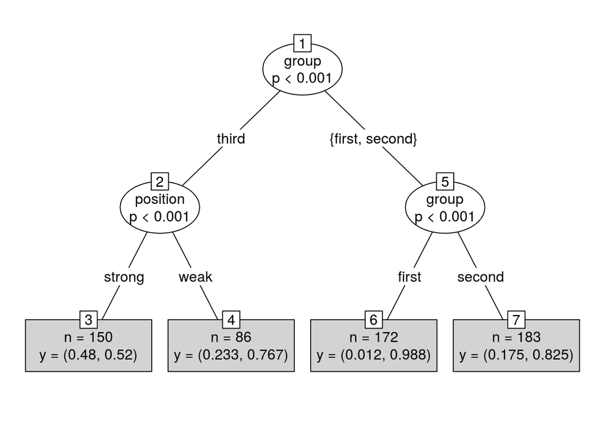

```r
plot(fit, type = "simple") # a simplified view
```

```r
predict(fit, df[45,-1], response = TRUE)
```

```
## [1] yes
## Levels: no yes
```

```r
fit2 <- cforest(v.elision~., data = df, control=cforest_unbiased(ntree=1000, mtry=3))
predict(fit2, df[45,-1],OOB=TRUE)
```

```
##   [1] yes yes yes yes yes yes yes yes yes yes yes yes yes yes yes yes yes yes
##  [19] yes yes yes yes yes yes yes yes yes yes yes no  no  no  no  no  no  no
##  [37] no  no  no  no  no  no  no  no  no  no  no  no  no  no  no  no  no  no
##  [55] no  no  no  no  no  no  no  no  no  no  no  no  no  no  no  no  no  no
##  [73] no  no  no  no  no  yes yes yes yes yes yes yes yes yes yes yes yes yes
##  [91] yes yes yes yes yes yes yes yes yes yes yes yes yes yes yes yes yes yes
## [109] yes yes yes yes yes yes yes yes yes yes yes yes yes yes yes yes yes yes
## [127] yes yes yes yes yes yes yes yes yes yes yes yes yes yes yes yes yes yes
## [145] yes yes yes yes yes yes yes yes yes yes yes yes yes yes yes yes yes yes
## [163] yes yes yes yes yes yes yes yes yes yes yes yes yes yes yes yes yes yes
## [181] yes yes yes yes yes yes yes yes yes yes yes yes yes yes yes yes yes yes
## [199] yes yes yes yes yes yes yes yes yes yes yes yes yes yes yes yes yes yes
## [217] yes yes yes yes yes yes yes yes yes yes yes yes yes yes yes yes yes yes
## [235] yes yes yes yes yes yes yes yes yes yes yes yes yes yes yes yes yes yes
## [253] yes yes yes yes yes yes yes yes yes yes yes yes yes yes yes yes yes yes
```

[output cut: 19 more lines]

```r
vi <- as.data.frame(sort(varimp(fit2), decreasing=TRUE))
vi
```

```
##          sort(varimp(fit2), decreasing = TRUE)
## group                               0.05798157
## position                            0.02479263
## word                                0.01991705
```

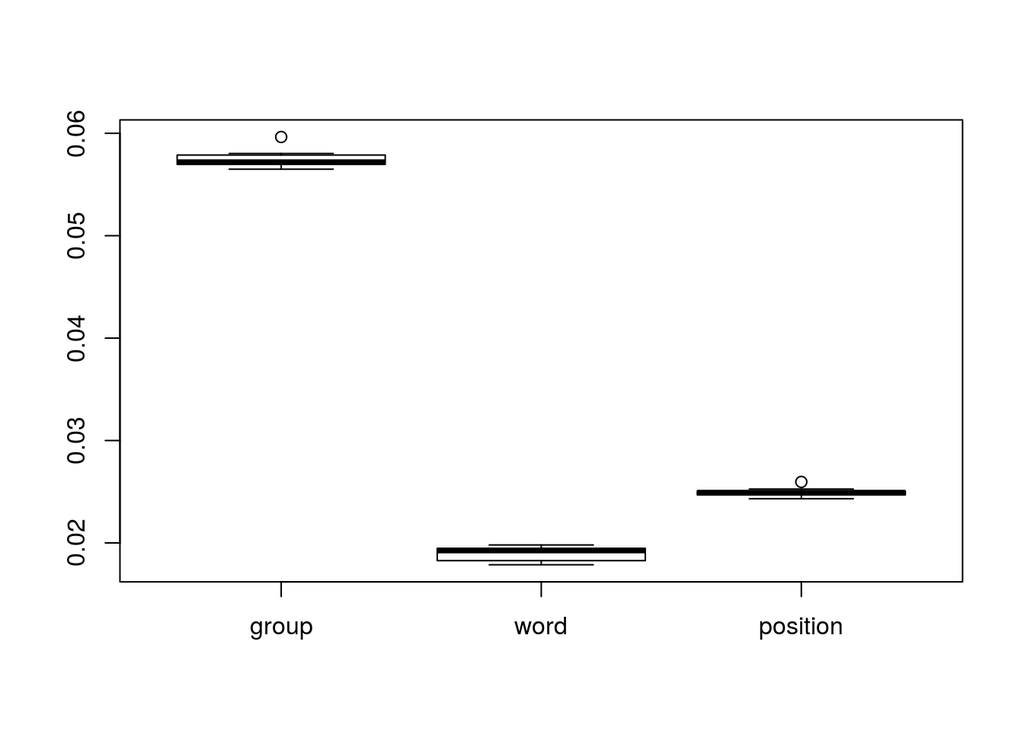

```r
vi1 <- t(replicate(10, varimp(fit2)))
boxplot(vi1)
```

Model accuracy:

```r
df.predicted <- predict(fit2, df[,-1], OOB=TRUE)
head(df.predicted)
```

```
## [1] yes yes yes yes yes yes
## Levels: no yes
```

```r
table(df[,1], df.predicted)
```

```
##      df.predicted
##        no yes
##   no   48  78
##   yes  34 431
```

```r
(sum(df[,1]==df.predicted)) / nrow(df) # accuracy
```

```
## [1] 0.8104907
```

### 2. /S/ deletion in Panamanian Spanish

Here’s some data from Henrietta Cedergren’s 1973 study of /s/-deletion in Panamanian Spanish (via Greg Guy and Scott Kiesling). Cedergren had noticed that speakers in Panama City, like in many dialects of Spanish, variably deleted the /s/ at the end of words. She undertook a study to find out if there was a change in progress:  
if final /s/ was systematically dropping out of Panamanian Spanish. The attached data are from interviews she performed across the city in four different social classes (`1` = highest, `2` = second highest, `3` = second lowest, `4` = lowest), to see how the variation was structured in the community. She also investigated the linguistic constraints on deletion, so she coded for a phonetic constraint — whether the following segment was consonant, vowel, or pause —- and the grammatical category of word that the /s/ is part of:  
* monomorpheme, where the $s$ is part of the free morpheme (e.g. *menos*)  
* verb, where the $s$ is the second singular inflection (e.g. *tu tienes*, *el tienes*)  
* determiner, where $s$ is plural marked on a determiner (e.g. *los*, *las*)  
* adjective, where $s$ is a nominal plural agreeing with the noun (e.g. *buenos*)  
* noun, where $s$ marks a plural noun (e.g. amigos)  
Fit the CART model predicting the $s$ deletion by phonetic environment and social class.  
Data: https://raw.githubusercontent.com/LingData2019/LingData/master/data/cedergren73.csv  
2.1 Visualize a model using plot() function. What is the number of observation in node 6?  
2.2 Visualize a model using print() function. Which split have a statistic 61.559 (e. g. pause, vowel vs. consonant)?  
2.3 Predict a value of s.delition for word said by person from 1 class, before consonant.  
Fit a `cforest` model using additional argument controls=cforest_unbiased(ntree=100, mtry=2).  
2.4 Calculate a variable importance for the random forest model using varimp() function. Which of the variable is more important?

```r
df <- read.csv("https://raw.githubusercontent.com/LingData2019/LingData/master/data/cedergren73.csv")
str(df)
```

```
## 'data.frame':    8846 obs. of  4 variables:
##  $ s.deletion: Factor w/ 2 levels "no","yes": 2 2 2 2 2 2 2 2 2 2 ...
##  $ gramm.cat : Factor w/ 5 levels "adjective","determiner",..: 4 4 4 4 4 4 4 4 4 4 ...
##  $ phon.cont : Factor w/ 3 levels "consonant","pause",..: 1 1 1 1 1 1 1 1 1 1 ...
##  $ social    : int  1 1 1 1 1 1 1 1 1 1 ...
```

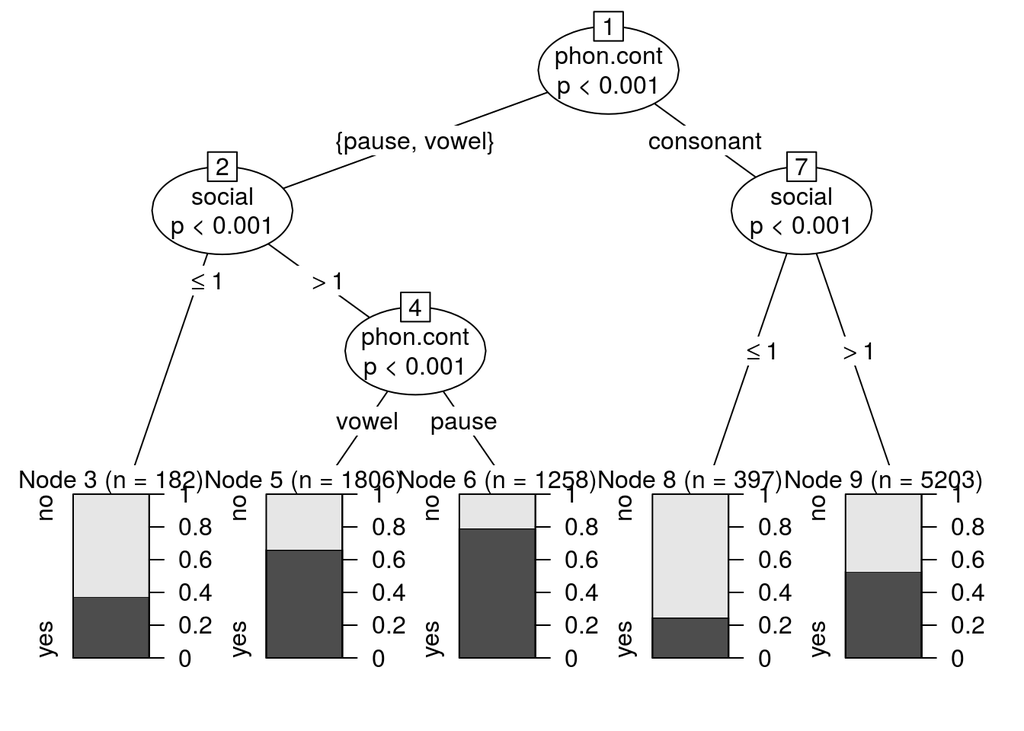

```r
fit <- ctree(s.deletion~phon.cont+social, data = df)
plot(fit)
```

```r
print(fit)
```

```
##
##   Conditional inference tree with 5 terminal nodes
##
## Response:  s.deletion
## Inputs:  phon.cont, social
## Number of observations:  8846
##
## 1) phon.cont == {pause, vowel}; criterion = 1, statistic = 344.156
##   2) social <= 1; criterion = 1, statistic = 92.762
##     3)*  weights = 182
##   2) social > 1
##     4) phon.cont == {vowel}; criterion = 1, statistic = 61.559
##       5)*  weights = 1806
##     4) phon.cont == {pause}
##       6)*  weights = 1258
## 1) phon.cont == {consonant}
##   7) social <= 1; criterion = 1, statistic = 118.054
##     8)*  weights = 397
##   7) social > 1
##     9)*  weights = 5203
```

```r
predict(fit, df[1,-c(1:2)], response = TRUE)
```

```
## [1] no
## Levels: no yes
```

```r
fit2 <- cforest(s.deletion~., data = df, controls=cforest_unbiased(ntree=100, mtry=2))
varimp(fit2)
```

```
##  gramm.cat  phon.cont     social
## 0.03446390 0.01189555 0.02083564
```

```r
varimpAUC(fit2)
```

```
##   gramm.cat   phon.cont      social
## -0.04923258 -0.05999200 -0.02963368
```

### 3. Vowel reduction in Russian

Pavel Duryagin ran an experiment on perception of vowel reduction in Russian language. The dataset shva includes the following variables:  
* `time1` - reaction time 1  
* `duration` - duration of the vowel in the stimuly (in milliseconds, ms)  
* `time2` - reaction time 2  
* `f1`, `f2`, `f3` - the 1st, 2nd and 3rd formant of the vowel measured in Hz  
* `vowel` - vowel classified according the 3-fold classification (A - a under stress, a - a/o as in the first syllable before the stressed one, y (stands for shva) - a/o as in the second etc. syllable before the stressed one or after the stressed syllable, cf. `g[y]g[a]t[A]l[y]` *gogotala* `guffawed’). The dataset is available at https://raw.githubusercontent.com/agricolamz/2018-MAG_R_course/master/data/duryagin_ReductionRussian.txt. Fit the CART model predicting vowel by f1 and f2.  
3.1 Visualize a model using plot() function. What is the number of observation in node 9?  
3.2 Predict a value of vowel for sound with f1 = 600, f2 = 1300?  
Fit a cforest model using additional argument controls=cforest_unbiased(ntree=100, mtry=2).  
3.3 Predict a value of vowel for sound with f1 = 600, f2 = 1300?  
You need to add an argument OOB=TRUE.  
3.4 Calculate a variable importance for the random forest model using varimp() function. Which of the variable is more important?

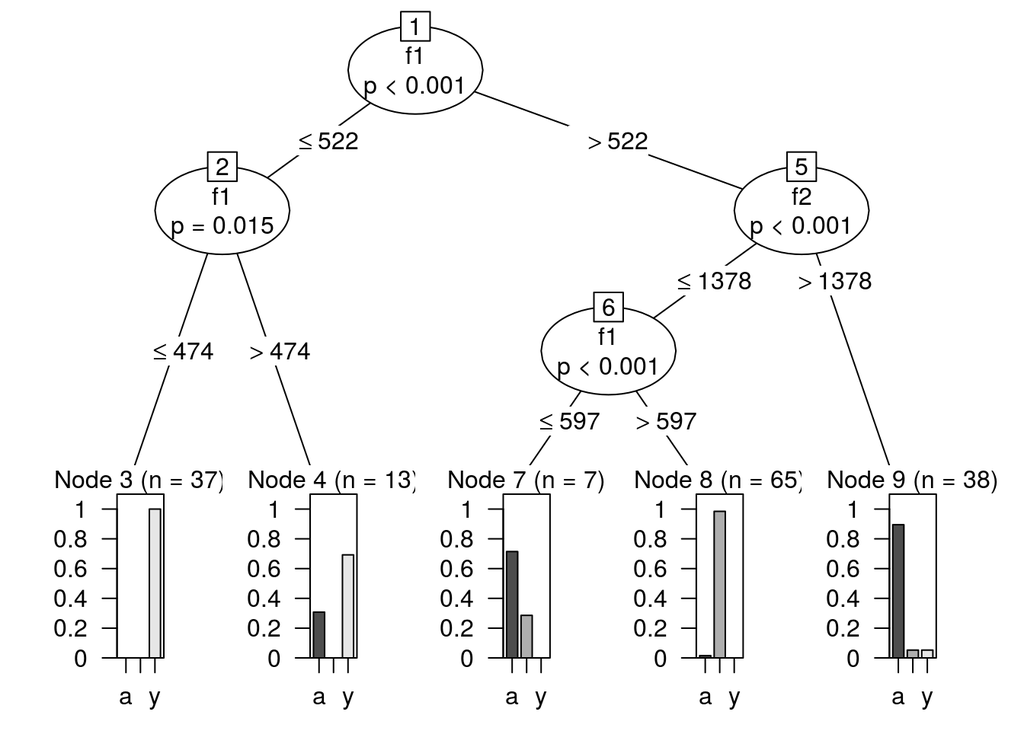

```r
shva <- read.csv("https://raw.githubusercontent.com/agricolamz/2018-MAG_R_course/master/data/duryagin_ReductionRussian.txt", sep = "\t")
fit <- ctree(vowel~f1+f2, data = shva)
plot(fit)
```

```r
print(fit)
```

```
##
##   Conditional inference tree with 5 terminal nodes
##
## Response:  vowel
## Inputs:  f1, f2
## Number of observations:  160
##
## 1) f1 <= 522; criterion = 1, statistic = 127.646
##   2) f1 <= 474; criterion = 0.985, statistic = 7.134
##     3)*  weights = 37
##   2) f1 > 474
##     4)*  weights = 13
## 1) f1 > 522
##   5) f2 <= 1378; criterion = 1, statistic = 66.584
##     6) f1 <= 597; criterion = 1, statistic = 21.42
##       7)*  weights = 7
##     6) f1 > 597
##       8)*  weights = 65
##   5) f2 > 1378
##     9)*  weights = 38
```

```r
predict(fit, newdata = data.frame(f1 = as.integer(600),
                        f2 = as.integer(1300)), response = TRUE)
```

```
## [1] A
## Levels: a A y
```

```r
fit2 <- cforest(vowel~f1+f2, data = shva, controls=cforest_unbiased(ntree=100, mtry=2))
varimp(fit2)
```

```
##        f1        f2
## 0.4353448 0.1112069
```

```r
predict(fit2, newdata = data.frame(f1 = as.integer(600),
                        f2 = as.integer(1300)),OOB=TRUE)
```

```
## [1] A
## Levels: a A y
```

```r
fit
```

```
##
##   Conditional inference tree with 5 terminal nodes
##
## Response:  vowel
## Inputs:  f1, f2
## Number of observations:  160
##
## 1) f1 <= 522; criterion = 1, statistic = 127.646
##   2) f1 <= 474; criterion = 0.985, statistic = 7.134
##     3)*  weights = 37
##   2) f1 > 474
##     4)*  weights = 13
## 1) f1 > 522
##   5) f2 <= 1378; criterion = 1, statistic = 66.584
##     6) f1 <= 597; criterion = 1, statistic = 21.42
##       7)*  weights = 7
##     6) f1 > 597
##       8)*  weights = 65
##   5) f2 > 1378
##     9)*  weights = 38
```

### References

- on bias in RF variable importance metrics [R blog](https://www.r-bloggers.com/be-aware-of-bias-in-rf-variable-importance-metrics/)
- trees and forests with diferent R packages [link](https://rpubs.com/YorkLin/cb103_20181106)